# **INTERNSHIP STUDIO PROJECT :- MARKETING CAMPAIGN FOR BANK PRODUCTS**

This project is about a bank finding the more reliable persons for converting them to person loan customers. They have a previous experience of doing a campaign and collected the data from different customers and found that 9 percent of 5000 people converted to personal loan customers. So they dont want to waste time again this this time for visiting all 5000 customers just for mere 9 percent though it was healthy. So we need to build a model such that we can filter customers who have maximum probability to convert into personal loan customers so that the bank can concentrate on those people only and can easily increase the percentage and reduce the cost for campaign this time.

# **1)Laoding the data and analysis**

**First we import all the required libraries for the project**

```python
import numpy as np
import pandas as pd
import matplotlib.pyplot as plt
import seaborn as sns
```

**we now load the data**

```python
data=pd.read_csv(r"C:\Users\LAKSHMI SAI KRISHNA\Desktop\Bank_Personal_Loan_Modelling.csv")
```

```python
data
```

|  | ID | Age | Experience | Income | ZIP Code | Family | CCAvg | Education | Mortgage | Personal Loan | Securities Account | CD Account | Online | CreditCard |
| --- | --- | --- | --- | --- | --- | --- | --- | --- | --- | --- | --- | --- | --- | --- |
| 0 | 1 | 25 | 1 | 49 | 91107 | 4 | 1.6 | 1 | 0 | 0 | 1 | 0 | 0 | 0 |
| 1 | 2 | 45 | 19 | 34 | 90089 | 3 | 1.5 | 1 | 0 | 0 | 1 | 0 | 0 | 0 |
| 2 | 3 | 39 | 15 | 11 | 94720 | 1 | 1.0 | 1 | 0 | 0 | 0 | 0 | 0 | 0 |
| 3 | 4 | 35 | 9 | 100 | 94112 | 1 | 2.7 | 2 | 0 | 0 | 0 | 0 | 0 | 0 |
| 4 | 5 | 35 | 8 | 45 | 91330 | 4 | 1.0 | 2 | 0 | 0 | 0 | 0 | 0 | 1 |
| ... | ... | ... | ... | ... | ... | ... | ... | ... | ... | ... | ... | ... | ... | ... |
| 4995 | 4996 | 29 | 3 | 40 | 92697 | 1 | 1.9 | 3 | 0 | 0 | 0 | 0 | 1 | 0 |
| 4996 | 4997 | 30 | 4 | 15 | 92037 | 4 | 0.4 | 1 | 85 | 0 | 0 | 0 | 1 | 0 |
| 4997 | 4998 | 63 | 39 | 24 | 93023 | 2 | 0.3 | 3 | 0 | 0 | 0 | 0 | 0 | 0 |
| 4998 | 4999 | 65 | 40 | 49 | 90034 | 3 | 0.5 | 2 | 0 | 0 | 0 | 0 | 1 | 0 |
| 4999 | 5000 | 28 | 4 | 83 | 92612 | 3 | 0.8 | 1 | 0 | 0 | 0 | 0 | 1 | 1 |

5000 rows × 14 columns

**let us check out the shape, size, dtypes,no of dimensions of the data**

```python
data.shape
```

```
(5000, 14)
```

```python
data.size
```

```
70000
```

```python
data.dtypes
```

```
ID                      int64
Age                     int64
Experience              int64
Income                  int64
ZIP Code                int64
Family                  int64
CCAvg                 float64
Education               int64
Mortgage                int64
Personal Loan           int64
Securities Account      int64
CD Account              int64
Online                  int64
CreditCard              int64
dtype: object
```

```python
data.ndim
```

```
2
```

**List of column names**

```python
data.columns
```

```
Index(['ID', 'Age', 'Experience', 'Income', 'ZIP Code', 'Family', 'CCAvg',
       'Education', 'Mortgage', 'Personal Loan', 'Securities Account',
       'CD Account', 'Online', 'CreditCard'],
      dtype='object')
```

**First 5 rows and last 5 rows of the data**

```python
data.head()
```

|  | ID | Age | Experience | Income | ZIP Code | Family | CCAvg | Education | Mortgage | Personal Loan | Securities Account | CD Account | Online | CreditCard |
| --- | --- | --- | --- | --- | --- | --- | --- | --- | --- | --- | --- | --- | --- | --- |
| 0 | 1 | 25 | 1 | 49 | 91107 | 4 | 1.6 | 1 | 0 | 0 | 1 | 0 | 0 | 0 |
| 1 | 2 | 45 | 19 | 34 | 90089 | 3 | 1.5 | 1 | 0 | 0 | 1 | 0 | 0 | 0 |
| 2 | 3 | 39 | 15 | 11 | 94720 | 1 | 1.0 | 1 | 0 | 0 | 0 | 0 | 0 | 0 |
| 3 | 4 | 35 | 9 | 100 | 94112 | 1 | 2.7 | 2 | 0 | 0 | 0 | 0 | 0 | 0 |
| 4 | 5 | 35 | 8 | 45 | 91330 | 4 | 1.0 | 2 | 0 | 0 | 0 | 0 | 0 | 1 |

```python
data.tail()
```

|  | ID | Age | Experience | Income | ZIP Code | Family | CCAvg | Education | Mortgage | Personal Loan | Securities Account | CD Account | Online | CreditCard |
| --- | --- | --- | --- | --- | --- | --- | --- | --- | --- | --- | --- | --- | --- | --- |
| 4995 | 4996 | 29 | 3 | 40 | 92697 | 1 | 1.9 | 3 | 0 | 0 | 0 | 0 | 1 | 0 |
| 4996 | 4997 | 30 | 4 | 15 | 92037 | 4 | 0.4 | 1 | 85 | 0 | 0 | 0 | 1 | 0 |
| 4997 | 4998 | 63 | 39 | 24 | 93023 | 2 | 0.3 | 3 | 0 | 0 | 0 | 0 | 0 | 0 |
| 4998 | 4999 | 65 | 40 | 49 | 90034 | 3 | 0.5 | 2 | 0 | 0 | 0 | 0 | 1 | 0 |
| 4999 | 5000 | 28 | 4 | 83 | 92612 | 3 | 0.8 | 1 | 0 | 0 | 0 | 0 | 1 | 1 |

**Info regarding the data**

```python
data.info()
```

```
<class 'pandas.core.frame.DataFrame'>
RangeIndex: 5000 entries, 0 to 4999
Data columns (total 14 columns):
 #   Column              Non-Null Count  Dtype
---  ------              --------------  -----
 0   ID                  5000 non-null   int64
 1   Age                 5000 non-null   int64
 2   Experience          5000 non-null   int64
 3   Income              5000 non-null   int64
 4   ZIP Code            5000 non-null   int64
 5   Family              5000 non-null   int64
 6   CCAvg               5000 non-null   float64
 7   Education           5000 non-null   int64
 8   Mortgage            5000 non-null   int64
 9   Personal Loan       5000 non-null   int64
 10  Securities Account  5000 non-null   int64
 11  CD Account          5000 non-null   int64
 12  Online              5000 non-null   int64
 13  CreditCard          5000 non-null   int64
dtypes: float64(1), int64(13)
memory usage: 547.0 KB
```

**From info the observed points are**

1. there are total 5000 rows in the given dataset
2. there are 14 columns in the given dataset
3. out of all the 14 columns 13 columns are of integer type and only 1 column is of float datatype
4. there are no null values in the data

## **Statistical summary of data**

```python
data.describe()
```

|  | ID | Age | Experience | Income | ZIP Code | Family | CCAvg | Education | Mortgage | Personal Loan | Securities Account | CD Account | Online | CreditCard |
| --- | --- | --- | --- | --- | --- | --- | --- | --- | --- | --- | --- | --- | --- | --- |
| count | 5000.000000 | 5000.000000 | 5000.000000 | 5000.000000 | 5000.000000 | 5000.000000 | 5000.000000 | 5000.000000 | 5000.000000 | 5000.000000 | 5000.000000 | 5000.00000 | 5000.000000 | 5000.000000 |
| mean | 2500.500000 | 45.338400 | 20.104600 | 73.774200 | 93152.503000 | 2.396400 | 1.937938 | 1.881000 | 56.498800 | 0.096000 | 0.104400 | 0.06040 | 0.596800 | 0.294000 |
| std | 1443.520003 | 11.463166 | 11.467954 | 46.033729 | 2121.852197 | 1.147663 | 1.747659 | 0.839869 | 101.713802 | 0.294621 | 0.305809 | 0.23825 | 0.490589 | 0.455637 |
| min | 1.000000 | 23.000000 | -3.000000 | 8.000000 | 9307.000000 | 1.000000 | 0.000000 | 1.000000 | 0.000000 | 0.000000 | 0.000000 | 0.00000 | 0.000000 | 0.000000 |
| 25% | 1250.750000 | 35.000000 | 10.000000 | 39.000000 | 91911.000000 | 1.000000 | 0.700000 | 1.000000 | 0.000000 | 0.000000 | 0.000000 | 0.00000 | 0.000000 | 0.000000 |
| 50% | 2500.500000 | 45.000000 | 20.000000 | 64.000000 | 93437.000000 | 2.000000 | 1.500000 | 2.000000 | 0.000000 | 0.000000 | 0.000000 | 0.00000 | 1.000000 | 0.000000 |
| 75% | 3750.250000 | 55.000000 | 30.000000 | 98.000000 | 94608.000000 | 3.000000 | 2.500000 | 3.000000 | 101.000000 | 0.000000 | 0.000000 | 0.00000 | 1.000000 | 1.000000 |
| max | 5000.000000 | 67.000000 | 43.000000 | 224.000000 | 96651.000000 | 4.000000 | 10.000000 | 3.000000 | 635.000000 | 1.000000 | 1.000000 | 1.00000 | 1.000000 | 1.000000 |

```python
data.mean()
```

```
ID                     2500.500000
Age                      45.338400
Experience               20.104600
Income                   73.774200
ZIP Code              93152.503000
Family                    2.396400
CCAvg                     1.937938
Education                 1.881000
Mortgage                 56.498800
Personal Loan             0.096000
Securities Account        0.104400
CD Account                0.060400
Online                    0.596800
CreditCard                0.294000
dtype: float64
```

```python
data['Age'].mean()
```

```
45.3384
```

```python
data['Age'].max()
```

```
67
```

```python
data['Age'].min()
```

```
23
```

### **Let us check for any null values present in data**

```python
data.isna()
#this just gives boolean values throughout the table
```

|  | ID | Age | Experience | Income | ZIP Code | Family | CCAvg | Education | Mortgage | Personal Loan | Securities Account | CD Account | Online | CreditCard |
| --- | --- | --- | --- | --- | --- | --- | --- | --- | --- | --- | --- | --- | --- | --- |
| 0 | False | False | False | False | False | False | False | False | False | False | False | False | False | False |
| 1 | False | False | False | False | False | False | False | False | False | False | False | False | False | False |
| 2 | False | False | False | False | False | False | False | False | False | False | False | False | False | False |
| 3 | False | False | False | False | False | False | False | False | False | False | False | False | False | False |
| 4 | False | False | False | False | False | False | False | False | False | False | False | False | False | False |
| ... | ... | ... | ... | ... | ... | ... | ... | ... | ... | ... | ... | ... | ... | ... |
| 4995 | False | False | False | False | False | False | False | False | False | False | False | False | False | False |
| 4996 | False | False | False | False | False | False | False | False | False | False | False | False | False | False |
| 4997 | False | False | False | False | False | False | False | False | False | False | False | False | False | False |
| 4998 | False | False | False | False | False | False | False | False | False | False | False | False | False | False |
| 4999 | False | False | False | False | False | False | False | False | False | False | False | False | False | False |

5000 rows × 14 columns

```python
pd.isnull(data).any(axis=1)
#this gives boolean along the axis 1 i.e rows for null values if any
```

```
0       False
1       False
2       False
3       False
4       False
        ...
4995    False
4996    False
4997    False
4998    False
4999    False
Length: 5000, dtype: bool
```

```python
data.isna().sum()
```

```
ID                    0
Age                   0
Experience            0
Income                0
ZIP Code              0
Family                0
CCAvg                 0
Education             0
Mortgage              0
Personal Loan         0
Securities Account    0
CD Account            0
Online                0
CreditCard            0
dtype: int64
```

```python
data[pd.isnull(data).any(axis=1)]
```

|  | ID | Age | Experience | Income | ZIP Code | Family | CCAvg | Education | Mortgage | Personal Loan | Securities Account | CD Account | Online | CreditCard |
| --- | --- | --- | --- | --- | --- | --- | --- | --- | --- | --- | --- | --- | --- | --- |

### **Therefore no rows are displayed which implies there are no missing values in the given dataset**

So there is no need to clean the null values since data is already free from null values but there is still some data cleaning required

# **2) Data Cleaning**

### it is very clear that id is just like a serial number and anyhow we had index for that purpose

#### Let us remove that column

```python
data=data.drop(labels="ID",axis=1)
```

```python
data.head()
```

|  | Age | Experience | Income | ZIP Code | Family | CCAvg | Education | Mortgage | Personal Loan | Securities Account | CD Account | Online | CreditCard |
| --- | --- | --- | --- | --- | --- | --- | --- | --- | --- | --- | --- | --- | --- |
| 0 | 25 | 1 | 49 | 91107 | 4 | 1.6 | 1 | 0 | 0 | 1 | 0 | 0 | 0 |
| 1 | 45 | 19 | 34 | 90089 | 3 | 1.5 | 1 | 0 | 0 | 1 | 0 | 0 | 0 |
| 2 | 39 | 15 | 11 | 94720 | 1 | 1.0 | 1 | 0 | 0 | 0 | 0 | 0 | 0 |
| 3 | 35 | 9 | 100 | 94112 | 1 | 2.7 | 2 | 0 | 0 | 0 | 0 | 0 | 0 |
| 4 | 35 | 8 | 45 | 91330 | 4 | 1.0 | 2 | 0 | 0 | 0 | 0 | 0 | 1 |

```python
data.shape
```

```
(5000, 13)
```

### From statistical summary we got to know that experience column has negative values and we dont konw whether the negative values are from data collection errors or they are signifying 0 experience

so we fill all the negative columns with the median of experience column

```python
int(np.median(data.Experience))
```

```
20
```

```python
data.Experience=data['Experience'].replace([-1,-2,-3],int(np.median(data['Experience'])))
```

```python
data.head()
```

|  | Age | Experience | Income | ZIP Code | Family | CCAvg | Education | Mortgage | Personal Loan | Securities Account | CD Account | Online | CreditCard |
| --- | --- | --- | --- | --- | --- | --- | --- | --- | --- | --- | --- | --- | --- |
| 0 | 25 | 1 | 49 | 91107 | 4 | 1.6 | 1 | 0 | 0 | 1 | 0 | 0 | 0 |
| 1 | 45 | 19 | 34 | 90089 | 3 | 1.5 | 1 | 0 | 0 | 1 | 0 | 0 | 0 |
| 2 | 39 | 15 | 11 | 94720 | 1 | 1.0 | 1 | 0 | 0 | 0 | 0 | 0 | 0 |
| 3 | 35 | 9 | 100 | 94112 | 1 | 2.7 | 2 | 0 | 0 | 0 | 0 | 0 | 0 |
| 4 | 35 | 8 | 45 | 91330 | 4 | 1.0 | 2 | 0 | 0 | 0 | 0 | 0 | 1 |

```python
data.Experience.describe()
```

```
count    5000.000000
mean       20.327600
std        11.253035
min         0.000000
25%        11.000000
50%        20.000000
75%        30.000000
max        43.000000
Name: Experience, dtype: float64
```

**Let us check for any duplicated rows so that we can keep the repeated rows only single time**

```python
data.duplicated().value_counts()
```

```
False    5000
dtype: int64
```

Therefore no duplicated rows in th cleaned dataframe

## Note:-

1. **Until now we cleaned the data as much as possible from the data analysis but still we dont know which columns are highly correlated so that we can remove one of them**
2. **It is hard here itself to identify these pairs of correlation**
3. **it will be easy if we use EDA and visualise the plots between columns to recognise any strong correlations**
4. **This we will do in the visualisation and do the left over cleaning there**

# **3) EDA (Exploratory Data Analysis)**

**Let us find all the unique values in each columns**

```python
data.dtypes.value_counts()
```

```
int64      12
float64     1
dtype: int64
```

```python
np.sort(data['Age'].unique())
```

```
array([23, 24, 25, 26, 27, 28, 29, 30, 31, 32, 33, 34, 35, 36, 37, 38, 39,
       40, 41, 42, 43, 44, 45, 46, 47, 48, 49, 50, 51, 52, 53, 54, 55, 56,
       57, 58, 59, 60, 61, 62, 63, 64, 65, 66, 67], dtype=int64)
```

```python
np.sort(data['Income'].unique())
```

```
array([  8,   9,  10,  11,  12,  13,  14,  15,  18,  19,  20,  21,  22,
        23,  24,  25,  28,  29,  30,  31,  32,  33,  34,  35,  38,  39,
        40,  41,  42,  43,  44,  45,  48,  49,  50,  51,  52,  53,  54,
        55,  58,  59,  60,  61,  62,  63,  64,  65,  68,  69,  70,  71,
        72,  73,  74,  75,  78,  79,  80,  81,  82,  83,  84,  85,  88,
        89,  90,  91,  92,  93,  94,  95,  98,  99, 100, 101, 102, 103,
       104, 105, 108, 109, 110, 111, 112, 113, 114, 115, 118, 119, 120,
       121, 122, 123, 124, 125, 128, 129, 130, 131, 132, 133, 134, 135,
       138, 139, 140, 141, 142, 143, 144, 145, 148, 149, 150, 151, 152,
       153, 154, 155, 158, 159, 160, 161, 162, 163, 164, 165, 168, 169,
       170, 171, 172, 173, 174, 175, 178, 179, 180, 181, 182, 183, 184,
       185, 188, 189, 190, 191, 192, 193, 194, 195, 198, 199, 200, 201,
       202, 203, 204, 205, 218, 224], dtype=int64)
```

```python
np.sort(data['Experience'].unique())
```

```
array([ 0,  1,  2,  3,  4,  5,  6,  7,  8,  9, 10, 11, 12, 13, 14, 15, 16,
       17, 18, 19, 20, 21, 22, 23, 24, 25, 26, 27, 28, 29, 30, 31, 32, 33,
       34, 35, 36, 37, 38, 39, 40, 41, 42, 43], dtype=int64)
```

```python
np.sort(data['ZIP Code'].unique())
```

```
array([ 9307, 90005, 90007, 90009, 90011, 90016, 90018, 90019, 90024,
       90025, 90027, 90028, 90029, 90032, 90033, 90034, 90035, 90036,
       90037, 90041, 90044, 90045, 90048, 90049, 90057, 90058, 90059,
       90064, 90065, 90066, 90068, 90071, 90073, 90086, 90089, 90095,
       90210, 90212, 90230, 90232, 90245, 90250, 90254, 90266, 90272,
       90274, 90275, 90277, 90280, 90291, 90304, 90401, 90404, 90405,
       90502, 90503, 90504, 90505, 90509, 90601, 90623, 90630, 90638,
       90639, 90640, 90650, 90717, 90720, 90740, 90745, 90747, 90755,
       90813, 90840, 91006, 91007, 91016, 91024, 91030, 91040, 91101,
       91103, 91105, 91107, 91109, 91116, 91125, 91129, 91203, 91207,
       91301, 91302, 91304, 91311, 91320, 91326, 91330, 91335, 91342,
       91343, 91345, 91355, 91360, 91361, 91365, 91367, 91380, 91401,
       91423, 91604, 91605, 91614, 91706, 91709, 91710, 91711, 91730,
       91741, 91745, 91754, 91763, 91765, 91768, 91770, 91773, 91775,
       91784, 91791, 91801, 91902, 91910, 91911, 91941, 91942, 91950,
```

[output cut: 38 more lines]

```python
np.sort(data['Family'].unique())
```

```
array([1, 2, 3, 4], dtype=int64)
```

```python
np.sort(data['CCAvg'].unique())
```

```
array([ 0.  ,  0.1 ,  0.2 ,  0.3 ,  0.4 ,  0.5 ,  0.6 ,  0.67,  0.7 ,
        0.75,  0.8 ,  0.9 ,  1.  ,  1.1 ,  1.2 ,  1.3 ,  1.33,  1.4 ,
        1.5 ,  1.6 ,  1.67,  1.7 ,  1.75,  1.8 ,  1.9 ,  2.  ,  2.1 ,
        2.2 ,  2.3 ,  2.33,  2.4 ,  2.5 ,  2.6 ,  2.67,  2.7 ,  2.75,
        2.8 ,  2.9 ,  3.  ,  3.1 ,  3.2 ,  3.25,  3.3 ,  3.33,  3.4 ,
        3.5 ,  3.6 ,  3.67,  3.7 ,  3.8 ,  3.9 ,  4.  ,  4.1 ,  4.2 ,
        4.25,  4.3 ,  4.33,  4.4 ,  4.5 ,  4.6 ,  4.67,  4.7 ,  4.75,
        4.8 ,  4.9 ,  5.  ,  5.1 ,  5.2 ,  5.3 ,  5.33,  5.4 ,  5.5 ,
        5.6 ,  5.67,  5.7 ,  5.8 ,  5.9 ,  6.  ,  6.1 ,  6.2 ,  6.3 ,
        6.33,  6.4 ,  6.5 ,  6.6 ,  6.67,  6.7 ,  6.8 ,  6.9 ,  7.  ,
        7.2 ,  7.3 ,  7.4 ,  7.5 ,  7.6 ,  7.8 ,  7.9 ,  8.  ,  8.1 ,
        8.2 ,  8.3 ,  8.5 ,  8.6 ,  8.8 ,  8.9 ,  9.  ,  9.3 , 10.  ])
```

```python
np.sort(data['Education'].unique())
```

```
array([1, 2, 3], dtype=int64)
```

```python
np.sort(data['Mortgage'].unique())
```

```
array([  0,  75,  76,  77,  78,  79,  80,  81,  82,  83,  84,  85,  86,
        87,  88,  89,  90,  91,  92,  93,  94,  95,  96,  97,  98,  99,
       100, 101, 102, 103, 104, 105, 106, 107, 108, 109, 110, 111, 112,
       113, 114, 115, 116, 117, 118, 119, 120, 121, 122, 123, 124, 125,
       126, 127, 128, 129, 130, 131, 132, 133, 134, 135, 136, 137, 138,
       139, 140, 141, 142, 143, 144, 145, 146, 147, 148, 149, 150, 151,
       152, 153, 154, 155, 156, 157, 158, 159, 160, 161, 162, 163, 164,
       165, 166, 167, 168, 169, 170, 171, 172, 173, 174, 175, 176, 177,
       178, 179, 180, 181, 182, 183, 184, 185, 186, 187, 188, 189, 190,
       191, 192, 193, 194, 195, 196, 197, 198, 199, 200, 201, 202, 203,
       204, 205, 206, 207, 208, 209, 210, 211, 212, 213, 214, 215, 216,
       217, 218, 219, 220, 221, 222, 223, 224, 225, 226, 227, 228, 229,
       230, 231, 232, 233, 234, 235, 236, 237, 238, 239, 240, 241, 242,
       243, 244, 245, 246, 247, 248, 249, 250, 251, 252, 253, 255, 256,
       257, 258, 259, 260, 262, 263, 264, 265, 266, 267, 268, 270, 271,
       272, 273, 275, 276, 277, 278, 280, 281, 282, 283, 284, 285, 286,
       287, 289, 290, 292, 293, 294, 295, 296, 297, 298, 299, 300, 301,
       302, 303, 304, 305, 306, 307, 308, 309, 310, 311, 312, 313, 314,
       315, 318, 319, 321, 322, 323, 325, 326, 327, 328, 329, 330, 331,
       333, 334, 336, 337, 341, 342, 343, 344, 345, 351, 352, 353, 354,
       355, 357, 358, 359, 360, 361, 364, 366, 368, 372, 373, 374, 378,
       380, 381, 382, 383, 385, 389, 391, 392, 394, 396, 397, 398, 400,
       402, 403, 405, 406, 408, 410, 412, 415, 416, 419, 421, 422, 427,
       428, 429, 431, 432, 433, 437, 442, 446, 449, 452, 455, 458, 461,
       464, 466, 467, 470, 475, 477, 481, 483, 485, 496, 500, 505, 508,
       509, 522, 524, 535, 541, 547, 550, 553, 565, 567, 569, 571, 577,
       581, 582, 587, 589, 590, 601, 612, 617, 635], dtype=int64)
```

```python
np.sort(data['Personal Loan'].unique())
```

```
array([0, 1], dtype=int64)
```

```python
np.sort(data['Securities Account'].unique())
```

```
array([0, 1], dtype=int64)
```

```python
np.sort(data['CD Account'].unique())
```

```
array([0, 1], dtype=int64)
```

```python
np.sort(data['Online'].unique())
```

```
array([0, 1], dtype=int64)
```

```python
np.sort(data['CreditCard'].unique())
```

```
array([0, 1], dtype=int64)
```

### **no of unique value in mortgage and other useful columns**

```python
data['Mortgage'].nunique()
```

```
347
```

```python
data['ZIP Code'].nunique()
```

```
467
```

```python
data.nunique()
```

```
Age                    45
Experience             44
Income                162
ZIP Code              467
Family                  4
CCAvg                 108
Education               3
Mortgage              347
Personal Loan           2
Securities Account      2
CD Account              2
Online                  2
CreditCard              2
dtype: int64
```

**Here the zip code is also like a serial number and had a lot of unique numbers i.e, 467 which are in a serial mostly, So we can remove this column**

```python
data=data.drop(labels='ZIP Code',axis=1)
```

```python
data.head()
```

|  | Age | Experience | Income | Family | CCAvg | Education | Mortgage | Personal Loan | Securities Account | CD Account | Online | CreditCard |
| --- | --- | --- | --- | --- | --- | --- | --- | --- | --- | --- | --- | --- |
| 0 | 25 | 1 | 49 | 4 | 1.6 | 1 | 0 | 0 | 1 | 0 | 0 | 0 |
| 1 | 45 | 19 | 34 | 3 | 1.5 | 1 | 0 | 0 | 1 | 0 | 0 | 0 |
| 2 | 39 | 15 | 11 | 1 | 1.0 | 1 | 0 | 0 | 0 | 0 | 0 | 0 |
| 3 | 35 | 9 | 100 | 1 | 2.7 | 2 | 0 | 0 | 0 | 0 | 0 | 0 |
| 4 | 35 | 8 | 45 | 4 | 1.0 | 2 | 0 | 0 | 0 | 0 | 0 | 1 |

### **no of 0 value in mortgage and credit cards columns**

```python
data['Mortgage'].value_counts()[0]
```

```
3462
```

```python
data['CreditCard'].value_counts()[0]
```

```
3530
```

### **value counts of all the categorical columns using a for loop**

```python
data.Education.value_counts()
```

```
1    2096
3    1501
2    1403
Name: Education, dtype: int64
```

```python
data.Family.value_counts()
```

```
1    1472
2    1296
4    1222
3    1010
Name: Family, dtype: int64
```

```python
for column in data.columns.to_list()[-5:]:
  print(column+": \n"+str(data[column].value_counts()))
```

```
Personal Loan:
0    4520
1     480
Name: Personal Loan, dtype: int64
Securities Account:
0    4478
1     522
Name: Securities Account, dtype: int64
CD Account:
0    4698
1     302
Name: CD Account, dtype: int64
Online:
1    2984
0    2016
Name: Online, dtype: int64
CreditCard:
0    3530
1    1470
Name: CreditCard, dtype: int64
```

## **Let us visualize the Data**

**we use seaborn pairplot to get graphs between all columns and then visualize the rquired pairs of columns after deciding from pairplot**

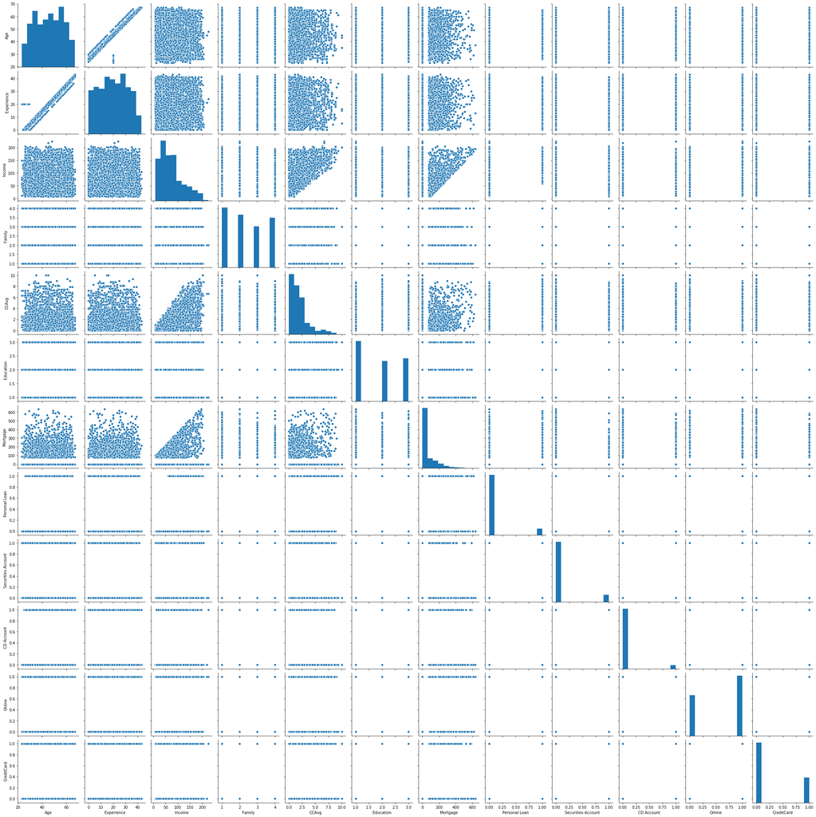

```python
sns.pairplot(data)
```

**It seems like age and experience are highly correlated**

**Let us visualize them using a scatter plot**

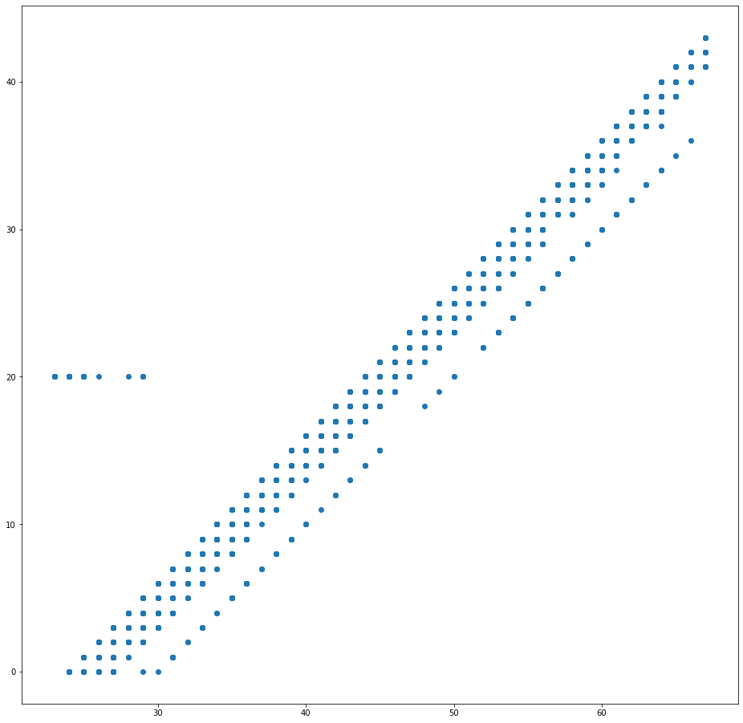

```python
fig=plt.figure(figsize=(16,16))
plt.scatter(data.Age,data.Experience)
```

### It is very clear from the graph that experience and age are highly correlated and even a few violation on the left is also due to replacement of negative values in experience to median otherwise thier would be a perfect correlation

```python
data.corr()
```

|  | Age | Experience | Income | Family | CCAvg | Education | Mortgage | Personal Loan | Securities Account | CD Account | Online | CreditCard |
| --- | --- | --- | --- | --- | --- | --- | --- | --- | --- | --- | --- | --- |
| Age | 1.000000 | 0.977182 | -0.055269 | -0.046418 | -0.052012 | 0.041334 | -0.012539 | -0.007726 | -0.000436 | 0.008043 | 0.013702 | 0.007681 |
| Experience | 0.977182 | 1.000000 | -0.049046 | -0.045528 | -0.048718 | 0.018074 | -0.013365 | -0.014013 | -0.000465 | 0.005526 | 0.013459 | 0.008834 |
| Income | -0.055269 | -0.049046 | 1.000000 | -0.157501 | 0.645984 | -0.187524 | 0.206806 | 0.502462 | -0.002616 | 0.169738 | 0.014206 | -0.002385 |
| Family | -0.046418 | -0.045528 | -0.157501 | 1.000000 | -0.109275 | 0.064929 | -0.020445 | 0.061367 | 0.019994 | 0.014110 | 0.010354 | 0.011588 |
| CCAvg | -0.052012 | -0.048718 | 0.645984 | -0.109275 | 1.000000 | -0.136124 | 0.109905 | 0.366889 | 0.015086 | 0.136534 | -0.003611 | -0.006689 |
| Education | 0.041334 | 0.018074 | -0.187524 | 0.064929 | -0.136124 | 1.000000 | -0.033327 | 0.136722 | -0.010812 | 0.013934 | -0.015004 | -0.011014 |
| Mortgage | -0.012539 | -0.013365 | 0.206806 | -0.020445 | 0.109905 | -0.033327 | 1.000000 | 0.142095 | -0.005411 | 0.089311 | -0.005995 | -0.007231 |
| Personal Loan | -0.007726 | -0.014013 | 0.502462 | 0.061367 | 0.366889 | 0.136722 | 0.142095 | 1.000000 | 0.021954 | 0.316355 | 0.006278 | 0.002802 |
| Securities Account | -0.000436 | -0.000465 | -0.002616 | 0.019994 | 0.015086 | -0.010812 | -0.005411 | 0.021954 | 1.000000 | 0.317034 | 0.012627 | -0.015028 |
| CD Account | 0.008043 | 0.005526 | 0.169738 | 0.014110 | 0.136534 | 0.013934 | 0.089311 | 0.316355 | 0.317034 | 1.000000 | 0.175880 | 0.278644 |
| Online | 0.013702 | 0.013459 | 0.014206 | 0.010354 | -0.003611 | -0.015004 | -0.005995 | 0.006278 | 0.012627 | 0.175880 | 1.000000 | 0.004210 |
| CreditCard | 0.007681 | 0.008834 | -0.002385 | 0.011588 | -0.006689 | -0.011014 | -0.007231 | 0.002802 | -0.015028 | 0.278644 | 0.004210 | 1.000000 |

**So now we can remove the experience column from the data since age can serve the purpose of both age and column at a time**

```python
data=data.drop(labels='Experience',axis=1)
```

```python
data.head()
```

|  | Age | Income | Family | CCAvg | Education | Mortgage | Personal Loan | Securities Account | CD Account | Online | CreditCard |
| --- | --- | --- | --- | --- | --- | --- | --- | --- | --- | --- | --- |
| 0 | 25 | 49 | 4 | 1.6 | 1 | 0 | 0 | 1 | 0 | 0 | 0 |
| 1 | 45 | 34 | 3 | 1.5 | 1 | 0 | 0 | 1 | 0 | 0 | 0 |
| 2 | 39 | 11 | 1 | 1.0 | 1 | 0 | 0 | 0 | 0 | 0 | 0 |
| 3 | 35 | 100 | 1 | 2.7 | 2 | 0 | 0 | 0 | 0 | 0 | 0 |
| 4 | 35 | 45 | 4 | 1.0 | 2 | 0 | 0 | 0 | 0 | 0 | 1 |

```python
data.shape
```

```
(5000, 11)
```

**We will continue with our visualisation part**

### Univariate Analysis

**We visualise each column individually so that we can know how they are distributed**

We generally dont need to visualise last five binary columns since there will be only bars which represent the count of 1 and 0 which we had already seen in EDA

**Age**

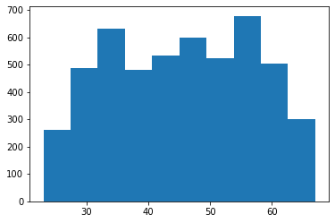

```python
plt.hist(data.Age)
```

**Mortgage**

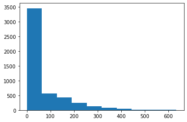

```python
plt.hist(data.Mortgage)
```

most of the data has Mortgage is inbetween 0 and 200 and is positively skewed

**CC Average**

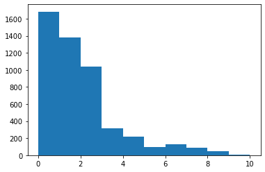

```python
plt.hist(data.CCAvg)
```

most of the data has cca average inbetween 0 and 3 and is positively skewed

**Income**

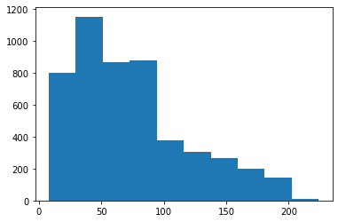

```python
plt.hist(data.Income)
```

most of the people have income 8 and 70 and positively skewed

**Family**

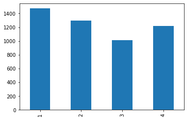

```python
data.Family.value_counts().sort_index().plot.bar()
```

most no of people have 1,2 or 4 family memebers

**Education**

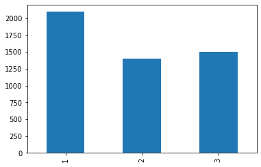

```python
data.Education.value_counts().sort_index().plot.bar()
```

most of the people have education level of 1 and the next highest is 3

**Let us check for outliers**

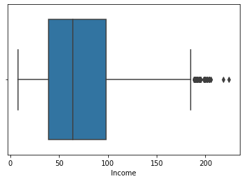

```python
sns.boxplot(data.Income)
```

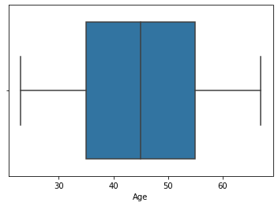

```python
sns.boxplot(data['Age'])
```

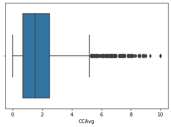

```python
sns.boxplot(data['CCAvg'])
```

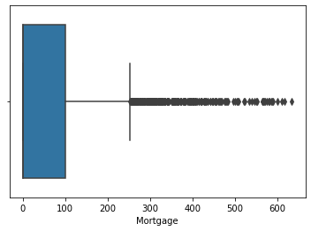

```python
sns.boxplot(data['Mortgage'])
```

**We can find that we have a few outliers in income, mortgage and cc average columns**

### Bivariate Analysis

As our target variable is personal loan we mainly focus the plots containing the personal loan

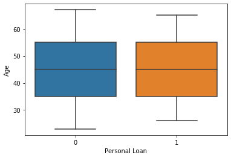

```python
sns.boxplot(x=data['Personal Loan'],y=data['Age'],data=data)
```

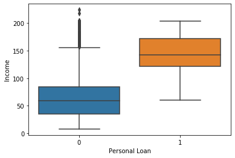

```python
sns.boxplot(x=data['Personal Loan'],y=data['Income'],data=data)
```

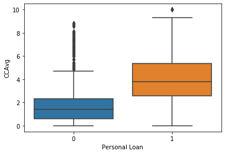

```python
sns.boxplot(x=data['Personal Loan'],y=data['CCAvg'],data=data)
```

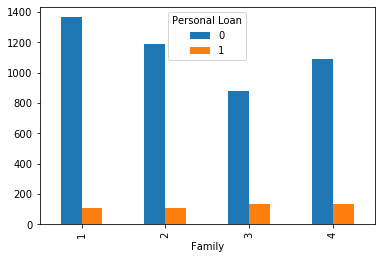

```python
pd.crosstab(data.Family,data['Personal Loan']).plot(kind="bar")
```

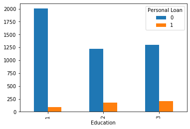

```python
pd.crosstab(data.Education,data['Personal Loan']).plot(kind="bar")
```

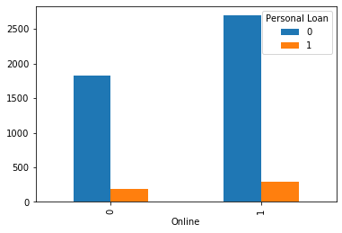

```python
pd.crosstab(data.Online,data['Personal Loan']).plot(kind="bar")
```

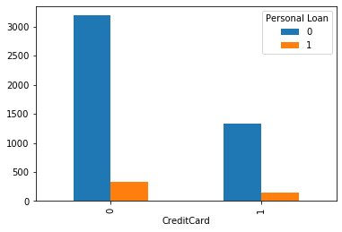

```python
pd.crosstab(data.CreditCard,data['Personal Loan']).plot(kind="bar")
```

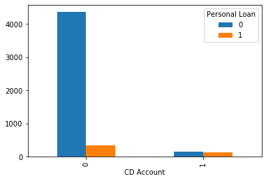

```python
pd.crosstab(data['CD Account'],data['Personal Loan']).plot(kind="bar")
```

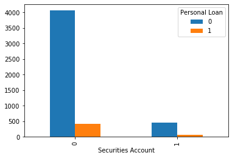

```python
pd.crosstab(data['Securities Account'],data['Personal Loan']).plot(kind="bar")
```

**Heatmap**

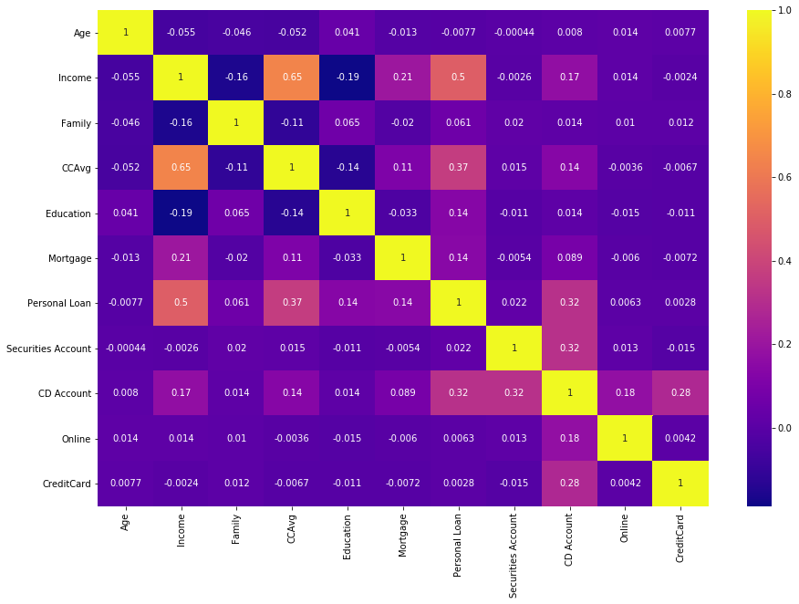

```python
fig,ax= plt.subplots(figsize=(15,10))
sns.heatmap(data.corr(),cmap='plasma',annot=True)
```

# 4) Transform the features

### In this part we remove any outliers since we had already done the remaining required feature transformations

**Let us use any of the two methods to find the outliers 1) IQR 2) Z-SCORE**

## a) IQR

```python
data
```

|  | Age | Income | Family | CCAvg | Education | Mortgage | Personal Loan | Securities Account | CD Account | Online | CreditCard |
| --- | --- | --- | --- | --- | --- | --- | --- | --- | --- | --- | --- |
| 0 | 25 | 49 | 4 | 1.6 | 1 | 0 | 0 | 1 | 0 | 0 | 0 |
| 1 | 45 | 34 | 3 | 1.5 | 1 | 0 | 0 | 1 | 0 | 0 | 0 |
| 2 | 39 | 11 | 1 | 1.0 | 1 | 0 | 0 | 0 | 0 | 0 | 0 |
| 3 | 35 | 100 | 1 | 2.7 | 2 | 0 | 0 | 0 | 0 | 0 | 0 |
| 4 | 35 | 45 | 4 | 1.0 | 2 | 0 | 0 | 0 | 0 | 0 | 1 |
| ... | ... | ... | ... | ... | ... | ... | ... | ... | ... | ... | ... |
| 4995 | 29 | 40 | 1 | 1.9 | 3 | 0 | 0 | 0 | 0 | 1 | 0 |
| 4996 | 30 | 15 | 4 | 0.4 | 1 | 85 | 0 | 0 | 0 | 1 | 0 |
| 4997 | 63 | 24 | 2 | 0.3 | 3 | 0 | 0 | 0 | 0 | 0 | 0 |
| 4998 | 65 | 49 | 3 | 0.5 | 2 | 0 | 0 | 0 | 0 | 1 | 0 |
| 4999 | 28 | 83 | 3 | 0.8 | 1 | 0 | 0 | 0 | 0 | 1 | 1 |

5000 rows × 11 columns

**Let us find first quantile, third quantile and inter quartile range**

```python
q1= data.quantile(0.25)
q3= data.quantile(0.75)
iqr=q3-q1
iqr
```

```
Age                    20.0
Income                 59.0
Family                  2.0
CCAvg                   1.8
Education               2.0
Mortgage              101.0
Personal Loan           0.0
Securities Account      0.0
CD Account              0.0
Online                  1.0
CreditCard              1.0
dtype: float64
```

**Let us remove the outliers that lie out of the 1.5 time iqr ranges**

```python
data1=data[~((data<(q1-1.5*iqr))|(data>(q3+1.5*iqr)))]
```

```python
data1.shape
```

```
(5000, 11)
```

```python
data1
```

|  | Age | Income | Family | CCAvg | Education | Mortgage | Personal Loan | Securities Account | CD Account | Online | CreditCard |
| --- | --- | --- | --- | --- | --- | --- | --- | --- | --- | --- | --- |
| 0 | 25 | 49.0 | 4 | 1.6 | 1 | 0.0 | 0.0 | NaN | 0.0 | 0 | 0 |
| 1 | 45 | 34.0 | 3 | 1.5 | 1 | 0.0 | 0.0 | NaN | 0.0 | 0 | 0 |
| 2 | 39 | 11.0 | 1 | 1.0 | 1 | 0.0 | 0.0 | 0.0 | 0.0 | 0 | 0 |
| 3 | 35 | 100.0 | 1 | 2.7 | 2 | 0.0 | 0.0 | 0.0 | 0.0 | 0 | 0 |
| 4 | 35 | 45.0 | 4 | 1.0 | 2 | 0.0 | 0.0 | 0.0 | 0.0 | 0 | 1 |
| ... | ... | ... | ... | ... | ... | ... | ... | ... | ... | ... | ... |
| 4995 | 29 | 40.0 | 1 | 1.9 | 3 | 0.0 | 0.0 | 0.0 | 0.0 | 1 | 0 |
| 4996 | 30 | 15.0 | 4 | 0.4 | 1 | 85.0 | 0.0 | 0.0 | 0.0 | 1 | 0 |
| 4997 | 63 | 24.0 | 2 | 0.3 | 3 | 0.0 | 0.0 | 0.0 | 0.0 | 0 | 0 |
| 4998 | 65 | 49.0 | 3 | 0.5 | 2 | 0.0 | 0.0 | 0.0 | 0.0 | 1 | 0 |
| 4999 | 28 | 83.0 | 3 | 0.8 | 1 | 0.0 | 0.0 | 0.0 | 0.0 | 1 | 1 |

5000 rows × 11 columns

## b) Z score

```python
from scipy.stats import zscore
```

**Calculate the absolute values of z score for ease of comparison**

```python
abs=np.abs(zscore(data))
```

```python
abs
```

```
array([[1.77441684, 0.53822878, 1.39741398, ..., 0.25354028, 1.21661774,
        0.64531434],
       [0.02952359, 0.8641094 , 0.52599094, ..., 0.25354028, 1.21661774,
        0.64531434],
       [0.55299157, 1.36379301, 1.21685513, ..., 0.25354028, 1.21661774,
        0.64531434],
       ...,
       [1.54088033, 1.08136314, 0.34543209, ..., 0.25354028, 1.21661774,
        0.64531434],
       [1.71536965, 0.53822878, 0.52599094, ..., 0.25354028, 0.82195086,
        0.64531434],
       [1.51268285, 0.20043396, 0.52599094, ..., 0.25354028, 0.82195086,
        1.54963239]])
```

**remove the rows with absolute z score greater than 3**

```python
filter=(abs<3).all(axis=1)
```

```python
filter
```

```
array([ True,  True,  True, ...,  True,  True,  True])
```

```python
dataf=data[filter]
```

```python
dataf
```

|  | Age | Income | Family | CCAvg | Education | Mortgage | Personal Loan | Securities Account | CD Account | Online | CreditCard |
| --- | --- | --- | --- | --- | --- | --- | --- | --- | --- | --- | --- |
| 0 | 25 | 49 | 4 | 1.6 | 1 | 0 | 0 | 1 | 0 | 0 | 0 |
| 1 | 45 | 34 | 3 | 1.5 | 1 | 0 | 0 | 1 | 0 | 0 | 0 |
| 2 | 39 | 11 | 1 | 1.0 | 1 | 0 | 0 | 0 | 0 | 0 | 0 |
| 3 | 35 | 100 | 1 | 2.7 | 2 | 0 | 0 | 0 | 0 | 0 | 0 |
| 4 | 35 | 45 | 4 | 1.0 | 2 | 0 | 0 | 0 | 0 | 0 | 1 |
| ... | ... | ... | ... | ... | ... | ... | ... | ... | ... | ... | ... |
| 4995 | 29 | 40 | 1 | 1.9 | 3 | 0 | 0 | 0 | 0 | 1 | 0 |
| 4996 | 30 | 15 | 4 | 0.4 | 1 | 85 | 0 | 0 | 0 | 1 | 0 |
| 4997 | 63 | 24 | 2 | 0.3 | 3 | 0 | 0 | 0 | 0 | 0 | 0 |
| 4998 | 65 | 49 | 3 | 0.5 | 2 | 0 | 0 | 0 | 0 | 1 | 0 |
| 4999 | 28 | 83 | 3 | 0.8 | 1 | 0 | 0 | 0 | 0 | 1 | 1 |

4223 rows × 11 columns

```python
for column in dataf.columns.to_list()[-5:]:
  print(column+": \n"+str(dataf[column].value_counts()))
```

```
Personal Loan:
0    4223
Name: Personal Loan, dtype: int64
Securities Account:
0    3870
1     353
Name: Securities Account, dtype: int64
CD Account:
0    4223
Name: CD Account, dtype: int64
Online:
1    2456
0    1767
Name: Online, dtype: int64
CreditCard:
0    3069
1    1154
Name: CreditCard, dtype: int64
```

### NOTE

**Here if we remove the 800 rows it is clear that personal loan column would have only 0's i.e rows with 1's are all removed , so we cannot build the model**

**As we have a lot of categorical data we better dont remove the outliers and we will continue with original data**

**Now we need to transform a few columns so that the skewedness that we observed in Univariate analysis can be removed**

We transform the age, income,ccaverage columns using log transform as remaining are categorical

```python
data
```

|  | Age | Income | Family | CCAvg | Education | Mortgage | Personal Loan | Securities Account | CD Account | Online | CreditCard |
| --- | --- | --- | --- | --- | --- | --- | --- | --- | --- | --- | --- |
| 0 | 25 | 49 | 4 | 1.6 | 1 | 0 | 0 | 1 | 0 | 0 | 0 |
| 1 | 45 | 34 | 3 | 1.5 | 1 | 0 | 0 | 1 | 0 | 0 | 0 |
| 2 | 39 | 11 | 1 | 1.0 | 1 | 0 | 0 | 0 | 0 | 0 | 0 |
| 3 | 35 | 100 | 1 | 2.7 | 2 | 0 | 0 | 0 | 0 | 0 | 0 |
| 4 | 35 | 45 | 4 | 1.0 | 2 | 0 | 0 | 0 | 0 | 0 | 1 |
| ... | ... | ... | ... | ... | ... | ... | ... | ... | ... | ... | ... |
| 4995 | 29 | 40 | 1 | 1.9 | 3 | 0 | 0 | 0 | 0 | 1 | 0 |
| 4996 | 30 | 15 | 4 | 0.4 | 1 | 85 | 0 | 0 | 0 | 1 | 0 |
| 4997 | 63 | 24 | 2 | 0.3 | 3 | 0 | 0 | 0 | 0 | 0 | 0 |
| 4998 | 65 | 49 | 3 | 0.5 | 2 | 0 | 0 | 0 | 0 | 1 | 0 |
| 4999 | 28 | 83 | 3 | 0.8 | 1 | 0 | 0 | 0 | 0 | 1 | 1 |

5000 rows × 11 columns

**As mortagage has so many zeros and the data is distributed very less after 100 we can better do binning process and convert mortgage to a categorical data**

```python
data['Mortgage'] = pd.cut(data['Mortgage'],bins=[0,100,200,300,400,500,600,700],labels=[0,1,2,3,4,5,6],include_lowest=True)
```

```python
data.Mortgage.value_counts()
```

```
0    3744
1     758
2     297
3     128
4      48
5      21
6       4
Name: Mortgage, dtype: int64
```

```python
data.isnull().value_counts()
```

```
Age    Income  Family  CCAvg  Education  Mortgage  Personal Loan  Securities Account  CD Account  Online  CreditCard
False  False   False   False  False      False     False          False               False       False   False         5000
dtype: int64
```

**Now let us extract age, income and cc avg columns so to reduce complex and long codes**

```python
datan=data[['Age','Income','CCAvg',]]
```

```python
datan
```

|  | Age | Income | CCAvg |
| --- | --- | --- | --- |
| 0 | 25 | 49 | 1.6 |
| 1 | 45 | 34 | 1.5 |
| 2 | 39 | 11 | 1.0 |
| 3 | 35 | 100 | 2.7 |
| 4 | 35 | 45 | 1.0 |
| ... | ... | ... | ... |
| 4995 | 29 | 40 | 1.9 |
| 4996 | 30 | 15 | 0.4 |
| 4997 | 63 | 24 | 0.3 |
| 4998 | 65 | 49 | 0.5 |
| 4999 | 28 | 83 | 0.8 |

5000 rows × 3 columns

**We use log transform to remove the skewedness from these three columns**

```python
datan=np.log(datan+1)
```

```python
datan
```

|  | Age | Income | CCAvg |
| --- | --- | --- | --- |
| 0 | 3.258097 | 3.912023 | 0.955511 |
| 1 | 3.828641 | 3.555348 | 0.916291 |
| 2 | 3.688879 | 2.484907 | 0.693147 |
| 3 | 3.583519 | 4.615121 | 1.308333 |
| 4 | 3.583519 | 3.828641 | 0.693147 |
| ... | ... | ... | ... |
| 4995 | 3.401197 | 3.713572 | 1.064711 |
| 4996 | 3.433987 | 2.772589 | 0.336472 |
| 4997 | 4.158883 | 3.218876 | 0.262364 |
| 4998 | 4.189655 | 3.912023 | 0.405465 |
| 4999 | 3.367296 | 4.430817 | 0.587787 |

5000 rows × 3 columns

```python
datan.isna().value_counts()
```

```
Age    Income  CCAvg
False  False   False    5000
dtype: int64
```

**Let us check out how our columns are distributed after transformation and whether the skewedness is removed or not**

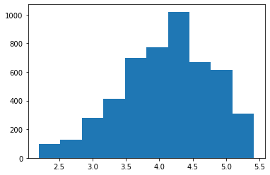

```python
plt.hist(datan.Income)
```

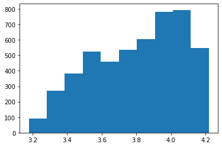

```python
plt.hist(datan.Age)
```

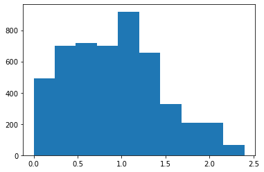

```python
plt.hist(datan.CCAvg)
```

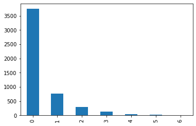

```python
data.Mortgage.value_counts().sort_index().plot.bar()
```

# 5) Normalising and splitting Data

**We use standard scaler to scale the data**

```python
from sklearn.preprocessing import StandardScaler
```

```python
datan.head()
```

|  | Age | Income | CCAvg |
| --- | --- | --- | --- |
| 0 | 3.258097 | 3.912023 | 0.955511 |
| 1 | 3.828641 | 3.555348 | 0.916291 |
| 2 | 3.688879 | 2.484907 | 0.693147 |
| 3 | 3.583519 | 4.615121 | 1.308333 |
| 4 | 3.583519 | 3.828641 | 0.693147 |

```python
scaler=StandardScaler()
```

```python
datan=scaler.fit_transform(datan)
```

```python
datan=pd.DataFrame(datan,columns=['Age','Income','CCAvg'])
```

```python
datan
```

|  | Age | Income | CCAvg |
| --- | --- | --- | --- |
| 0 | -2.092819 | -0.286700 | 0.049051 |
| 1 | 0.097306 | -0.811294 | -0.024503 |
| 2 | -0.439192 | -2.385689 | -0.442985 |
| 3 | -0.843634 | 0.747409 | 0.710731 |
| 4 | -0.843634 | -0.409337 | -0.442985 |
| ... | ... | ... | ... |
| 4995 | -1.543504 | -0.578579 | 0.253843 |
| 4996 | -1.417635 | -1.962569 | -1.111892 |
| 4997 | 1.364990 | -1.306174 | -1.250874 |
| 4998 | 1.483112 | -0.286700 | -0.982503 |
| 4999 | -1.673640 | 0.476337 | -0.640578 |

5000 rows × 3 columns

### we replace back the three columns we extracted previously from the main dataset as we have completed all the transformations and normalisations

```python
data[['Age','Income','CCAvg']]=datan
```

```python
data
```

|  | Age | Income | Family | CCAvg | Education | Mortgage | Personal Loan | Securities Account | CD Account | Online | CreditCard |
| --- | --- | --- | --- | --- | --- | --- | --- | --- | --- | --- | --- |
| 0 | -2.092819 | -0.286700 | 4 | 0.049051 | 1 | 0 | 0 | 1 | 0 | 0 | 0 |
| 1 | 0.097306 | -0.811294 | 3 | -0.024503 | 1 | 0 | 0 | 1 | 0 | 0 | 0 |
| 2 | -0.439192 | -2.385689 | 1 | -0.442985 | 1 | 0 | 0 | 0 | 0 | 0 | 0 |
| 3 | -0.843634 | 0.747409 | 1 | 0.710731 | 2 | 0 | 0 | 0 | 0 | 0 | 0 |
| 4 | -0.843634 | -0.409337 | 4 | -0.442985 | 2 | 0 | 0 | 0 | 0 | 0 | 1 |
| ... | ... | ... | ... | ... | ... | ... | ... | ... | ... | ... | ... |
| 4995 | -1.543504 | -0.578579 | 1 | 0.253843 | 3 | 0 | 0 | 0 | 0 | 1 | 0 |
| 4996 | -1.417635 | -1.962569 | 4 | -1.111892 | 1 | 0 | 0 | 0 | 0 | 1 | 0 |
| 4997 | 1.364990 | -1.306174 | 2 | -1.250874 | 3 | 0 | 0 | 0 | 0 | 0 | 0 |
| 4998 | 1.483112 | -0.286700 | 3 | -0.982503 | 2 | 0 | 0 | 0 | 0 | 1 | 0 |
| 4999 | -1.673640 | 0.476337 | 3 | -0.640578 | 1 | 0 | 0 | 0 | 0 | 1 | 1 |

5000 rows × 11 columns

```python
dataf.isna().value_counts()
```

```
Age    Income  Family  CCAvg  Education  Mortgage  Personal Loan  Securities Account  CD Account  Online  CreditCard
False  False   False   False  False      False     False          False               False       False   False         4223
dtype: int64
```

### We are done with all the data analysis required from simple cleaning to complex scaling

### Its time to move on to build our model with the cleaned and analytically prepared data

**befor building the model let us split our data into train and test sets**

Here we can see that the tasrget variable personal loan has only 9 percent 1,s and remaining zero so here normal splitting would cause loss of enough 1's to either of train or test sets So we use stratified sampling in order to have good enough no of 1's in both train and test sets

```python
from sklearn.model_selection import train_test_split
from sklearn.linear_model import LogisticRegression
```

**First of all we split the data into x and y and then later we sperate for train and test in both x and y**

```python
x=data.drop(labels='Personal Loan',axis=1)
```

```python
x
```

|  | Age | Income | Family | CCAvg | Education | Mortgage | Securities Account | CD Account | Online | CreditCard |
| --- | --- | --- | --- | --- | --- | --- | --- | --- | --- | --- |
| 0 | -2.092819 | -0.286700 | 4 | 0.049051 | 1 | 0 | 1 | 0 | 0 | 0 |
| 1 | 0.097306 | -0.811294 | 3 | -0.024503 | 1 | 0 | 1 | 0 | 0 | 0 |
| 2 | -0.439192 | -2.385689 | 1 | -0.442985 | 1 | 0 | 0 | 0 | 0 | 0 |
| 3 | -0.843634 | 0.747409 | 1 | 0.710731 | 2 | 0 | 0 | 0 | 0 | 0 |
| 4 | -0.843634 | -0.409337 | 4 | -0.442985 | 2 | 0 | 0 | 0 | 0 | 1 |
| ... | ... | ... | ... | ... | ... | ... | ... | ... | ... | ... |
| 4995 | -1.543504 | -0.578579 | 1 | 0.253843 | 3 | 0 | 0 | 0 | 1 | 0 |
| 4996 | -1.417635 | -1.962569 | 4 | -1.111892 | 1 | 0 | 0 | 0 | 1 | 0 |
| 4997 | 1.364990 | -1.306174 | 2 | -1.250874 | 3 | 0 | 0 | 0 | 0 | 0 |
| 4998 | 1.483112 | -0.286700 | 3 | -0.982503 | 2 | 0 | 0 | 0 | 1 | 0 |
| 4999 | -1.673640 | 0.476337 | 3 | -0.640578 | 1 | 0 | 0 | 0 | 1 | 1 |

5000 rows × 10 columns

```python
y=data[['Personal Loan']]
```

```python
y
```

|  | Personal Loan |
| --- | --- |
| 0 | 0 |
| 1 | 0 |
| 2 | 0 |
| 3 | 0 |
| 4 | 0 |
| ... | ... |
| 4995 | 0 |
| 4996 | 0 |
| 4997 | 0 |
| 4998 | 0 |
| 4999 | 0 |

5000 rows × 1 columns

### Stratified sampling

```python
xtr,xts,ytr,yts= train_test_split(x,y,test_size=0.3,stratify=y,random_state=0)
```

```python
xtr.shape
```

```
(3500, 10)
```

```python
ytr.shape
```

```
(3500, 1)
```

**Let us check the value counts of ytrain and ytest and ensure considerable no of 1's are present in both**

```python
ytr.value_counts()
```

```
Personal Loan
0                3164
1                 336
dtype: int64
```

```python
yts.value_counts()
```

```
Personal Loan
0                1356
1                 144
dtype: int64
```

**value counts look promising so let us move on to build the model**

# 6) Logistic Regression

**Now we implement and build the model and test for the accuracy**

**befor we fit the model we need to convert the ytrain to a numpy array and reshape it into required shape**

```python
ytrn=ytr.to_numpy()
ytrn=ytrn.reshape((3500,))
```

```python
clf = LogisticRegression(random_state=0).fit(xtr, ytrn)
```

### Let us evaluate the accuracy score of the classification on train and test sets

```python
clf.score(xtr,ytr)
```

```
0.9568571428571429
```

```python
clf.score(xts,yts)
```

```
0.956
```

**Here we did achieve accuracy of 95.6 percent in bith test and train set which is saying that our model is good in fitting and as well as predicting**

**As we completed our model next step is to evaluate the metrics so that we can get a clear understanding of our model and its performance**

**In order to evaluate metrics we need to get the prediction stes for training and test data**

```python
ytrp=clf.predict(xtr)
```

```python
ytrp=pd.DataFrame(ytrp,columns=['Personal Loan'])
```

```python
ytrp.value_counts()
```

```
Personal Loan
0                3241
1                 259
dtype: int64
```

```python
ytsp=pd.DataFrame(clf.predict(xts),columns=['Personal Loan'])
```

```python
ytsp.value_counts()
```

```
Personal Loan
0                1386
1                 114
dtype: int64
```

**We are ready with the required predictions sets to evaluate metrics**

# 7) Metrics

**let us evaluate different type of metrics**

### Importing the metrics library from sklearn

```python
from sklearn import metrics
```

### **Accuracy**

```python
metrics.accuracy_score(ytr,ytrp)
```

```
0.9568571428571429
```

```python
metrics.accuracy_score(yts,ytsp)
```

```
0.956
```

### Confusion matrix

```python
metrics.confusion_matrix(ytr,ytrp)
```

```
array([[3127,   37],
       [ 114,  222]], dtype=int64)
```

```python
metrics.confusion_matrix(yts,ytsp)
```

```
array([[1338,   18],
       [  48,   96]], dtype=int64)
```

### balanced_accuracy_score

```python
metrics.balanced_accuracy_score(ytr,ytrp)
```

```
0.8245101137800253
```

```python
metrics.balanced_accuracy_score(yts,ytsp)
```

```
0.8266961651917404
```

**We got this value 0.82 which is close to 1 so this metric was good**

### average_precision_score

```python
metrics.average_precision_score(ytr,ytrp)
```

```
0.5988979591836734
```

```python
metrics.average_precision_score(yts,ytsp)
```

```
0.5934035087719298
```

**This value 0.6 is not so close to one but somewhat good enough**

### F1 Score

```python
metrics.f1_score(ytr,ytrp)
```

```
0.7462184873949579
```

```python
metrics.f1_score(yts,ytsp)
```

```
0.744186046511628
```

**F1 Score is close to 0.74 which seems to be good enough since this is a cumulative measure of both precision and recall**

### Cross entropy loss

```python
metrics.log_loss(ytr,ytrp)
```

```
1.4901099487818381
```

```python
metrics.log_loss(yts,ytsp)
```

```
1.5197157565452333
```

### Mathew Correlation Coefficient

```python
metrics.matthews_corrcoef(ytr,ytrp)
```

```
0.7303931826354557
```

```python
metrics.matthews_corrcoef(yts,ytsp)
```

```
0.72635859911533
```

**Here we got value 0.73 close to 1 so this is good**

### Precision and Recall values

```python
metrics.recall_score(ytr,ytrp)
```

```
0.6607142857142857
```

```python
metrics.precision_score(ytr,ytrp)
```

```
0.8571428571428571
```

```python
metrics.recall_score(yts,ytsp)
```

```
0.6666666666666666
```

```python
metrics.precision_score(yts,ytsp)
```

```
0.8421052631578947
```

**Recall is somewhat low i.e, 0.66 but precesion is high i.e, 0.84 so overall we are having good tradeoff between precesion and recall**

### ROC AUC Score

```python
metrics.roc_auc_score(ytr,ytrp)
```

```
0.8245101137800251
```

```python
metrics.roc_auc_score(yts,ytsp)
```

```
0.8266961651917404
```

**Here we got roc auc value 0.82 which is greater than 0.5 and somewhat close to 1 so therefore we can sy that this is good enough**

### Conclusion:-

1. We can say that almost all of the metrics are giving good values especially f1 score and accuracy
2. So our basic regression model is working well on the transformed data
3. So the transformations on data are correct and we can proceed furthur

# 8) Other classification algorithms

**Its time we check our data with other classification metrics and check how our data responds as already our logistic classifier is doing good**

## a) Support Vector Machine ( SVM )

```python
from sklearn import svm
```

```python
clf = svm.SVC(random_state=1).fit(xtr,ytrn)
```

```python
clf.score(xtr,ytr)
```

```
0.9762857142857143
```

```python
clf.score(xts,yts)
```

```
0.98
```

```python
#confusion matrix for test set
ytsp=pd.DataFrame(clf.predict(xts),columns=['Personal Loan'])
print(metrics.confusion_matrix(yts,ytsp))
```

```
[[1353    3]
 [  27  117]]
```

**With SVM Algorithm we achieved a high accuracy of 97.6 and 98% which is an improvement to our normal classification model**

## b) Decision Tree

```python
from sklearn import tree
```

```python
clf = tree.DecisionTreeClassifier(max_depth=8,random_state=0).fit(xtr,ytrn)
```

```python
clf.score(xtr,ytr)
```

```
0.9954285714285714
```

```python
clf.score(xts,yts)
```

```
0.9826666666666667
```

```python
#confusion matrix for test set
ytsp=pd.DataFrame(clf.predict(xts),columns=['Personal Loan'])
print(metrics.confusion_matrix(yts,ytsp))
```

```
[[1345   11]
 [  15  129]]
```

**With decision tree Algorithm we achieved 99.5% accuracy on training set and 98% on test set which is an improvement to our SVM model**

## c) Random Forest ( Ensemble Method )

```python
from sklearn.ensemble import RandomForestClassifier
```

```python
clf = RandomForestClassifier(n_estimators=10,max_depth=8,random_state=0).fit(xtr,ytrn)
```

```python
clf.score(xtr,ytr)
```

```
0.9954285714285714
```

```python
clf.score(xts,yts)
```

```
0.9846666666666667
```

```python
#confusion matrix for test set
ytsp=pd.DataFrame(clf.predict(xts),columns=['Personal Loan'])
print(metrics.confusion_matrix(yts,ytsp))
```

```
[[1349    7]
 [  16  128]]
```

**With random forest Algorithm we achieved the best performance till now since we got 99.5% and 98.5% accuracy**

## d) Extra Trees Classifier ( Ensemble Method)

```python
from sklearn.ensemble import ExtraTreesClassifier
```

```python
clf = ExtraTreesClassifier(n_estimators=10, max_depth=12,min_samples_split=2, random_state=0).fit(xtr,ytrn)
```

```python
clf.score(xtr,ytr)
```

```
0.9868571428571429
```

```python
clf.score(xts,yts)
```

```
0.968
```

```python
#confusion matrix for test set
ytsp=pd.DataFrame(clf.predict(xts),columns=['Personal Loan'])
print(metrics.confusion_matrix(yts,ytsp))
```

```
[[1353    3]
 [  45   99]]
```

## e) Gradient Boosting

```python
from sklearn.ensemble import GradientBoostingClassifier
```

```python
clf = GradientBoostingClassifier(n_estimators=100, learning_rate=1.0,max_depth=1, random_state=0).fit(xtr,ytrn)
```

```python
clf.score(xtr,ytr)
```

```
0.9805714285714285
```

```python
clf.score(xts,yts)
```

```
0.9766666666666667
```

```python
#confusion matrix for test set
ytsp=pd.DataFrame(clf.predict(xts),columns=['Personal Loan'])
print(metrics.confusion_matrix(yts,ytsp))
```

```
[[1349    7]
 [  28  116]]
```

## Conclusion :-

**We have completed our project, before closing let us give a business understanding of our project**

# 9) Business Understanding

## Finally we are done with our project, so let us bring all the important points from different stages of our model and put them together for giving a business insights and understandings

### So there are two main parts where we can give a report they are EDA and model parts, so let us check them seperately

## Part 1:- EDA and univariate / bivariate analysis

**If we check for an ideal person with all these specifications we must get one**

```python
p=pd.DataFrame({'Age':0,'Income':1,'Family':3,'CCAvg':1,'Education':3,'Mortgage':0,'Securities Account':0,'CD Account':0,'Online':0,'CreditCard':0},index=range(0,1))
```

```python
p
```

|  | Age | Income | Family | CCAvg | Education | Mortgage | Securities Account | CD Account | Online | CreditCard |
| --- | --- | --- | --- | --- | --- | --- | --- | --- | --- | --- |
| 0 | 0 | 1 | 3 | 1 | 3 | 0 | 0 | 0 | 0 | 0 |

```python
# prediction of an ideal person with all good specifications
clf.predict(p)
```

```
array([1], dtype=int64)
```

**We got 1 which means that the specified conditions satisfy the model**

## Part 2 :- Model

**We will check all the models and then prefer the best one to use**

### Logistic Regression

train accuracy : 95.7

test accuracy : 95.6

confusion matrix:

[1338 , 18]

[ 48 , 96]

false negative = 48

false positive = 18

### SVM

train accuracy : 97.6

test accuracy : 98

confusion matrix:

[1353 , 3]

[ 27 , 117]

false negative = 27

false positive = 3

### Decesion Tree

train accuracy : 99.5

test accuracy : 98.26

confusion matrix:

[1345 , 11]

[ 15 , 129]

false negative = 15

false positive = 11

### Random forest

train accuracy : 99.5

confusion matrix:

[1349 , 7]

[ 16 , 128]

false negative = 16

false positive = 7

### Extrem Tree classifiers

train accuracy : 98.7

test accuracy : 96.8

confusion matrix:

[1353 , 3]

false negative = 45

false positive = 3

### Gradient boosting

train accuracy : 98

test accuracy : 97.6

confusion matrix:

[1349 , 7]

[ 28 , 116]

false negative = 28

false positive = 7

## Conclusion of PART 2

**After comparing all the models we can say that the random forest algorithm is the best model with high accuracies and very less false positives and negatives**

**Therefore use random forests algorithm**

# THANK YOU

NAME :-YARRU LAKSHMI SAI KRISHNA

EMAIL :- yarrulakshmisai111@gmail.com